# Inference of Cell-cell Communication for Ligand-receptor Pairs using TWCOM

07 May, 2024

```r
library(TWCOM)
library(Seurat)
library(CellChat)
```

This vignette demonstrates the detailed steps of inference and visualization of cell-cell communication for ligand-receptor pairs from spatially resolved transcriptomics (SRT) data. The corresponding data are from GSE144240.

# 1 Inference of cell-cell communication from spot-based SRT data

## 1.1 Data and preprocessing

**SRT gene expression matrix:** A gene expression matrix for the SRT data is necessary. Genes should be organized in rows with corresponding row names, while spots should be organized in columns with appropriate column names.

```r
data(STdata)
STdata[1:5, 1:5]  # raw count data
```

```
#>            spot1 spot2 spot3 spot4 spot5
#> FO538757.1     0     0     0     1     1
#> NOC2L          1     0     1     0     1
#> KLHL17         0     0     0     0     0
#> PLEKHN1        0     0     0     0     0
#> HES4           0     0     0     0     2
```

We require that the input gene expression matrix has been normalized. Here, we use `Seurat` to normalize the original gene expression matrix.

```r
dat <- CreateSeuratObject(counts=STdata, meta.data=STmeta)
dat <- NormalizeData(dat, assay = "RNA", scale.factor=10000)
```

```
#> Normalizing layer: counts
```

```r
stdat <- dat@assays$RNA$data
stdat[1:5, 1:5]  # normalized data
```

```
#> 5 x 5 sparse Matrix of class "dgCMatrix"
#>               spot1 spot2    spot3    spot4     spot5
#> FO538757.1 .            . .        1.405807 0.4925826
#> NOC2L      2.245586     . 1.729187 .        0.4925826
#> KLHL17     .            . .        .        .
#> PLEKHN1    .            . .        .        .
#> HES4       .            . .        .        0.8211333
```

**SRT location information:** A data frame containing X and Y coordinates for each spot is also necessary.

```r
data(STmeta)
head(STmeta)
```

```
#>        spot  x  y
#> spot1 spot1 10 10
#> spot2 spot2 10 12
#> spot3 spot3 10 14
#> spot4 spot4 10 16
#> spot5 spot5 10 18
#> spot6 spot6 10 20
```

**Cell type proportion matrix:** The information on cell type proportions can be obtained from upstream cell type deconvolution software, such as [RCTD](https://github.com/dmcable/spacexr), STRIDE, and SPOTlight. In this matrix, rows represent spots, and columns represent cell types.

```r
data(MExample)
MExample[1:5, 1:5]
```

```
#>               ASDC       B Cell         CD1C       CLEC9A     Eccrine
#> spot1 2.397727e-05 2.397727e-05 2.397727e-05 2.858981e-02 0.023976096
#> spot2 3.707897e-05 3.707897e-05 3.707897e-05 3.433518e-02 0.038124145
#> spot3 2.885173e-02 3.586799e-05 3.586799e-05 3.586799e-05 0.035130044
#> spot4 3.479057e-05 3.479057e-05 3.479057e-05 8.699541e-03 0.007237430
#> spot5 1.570955e-03 2.343515e-07 2.343515e-07 1.811005e-02 0.001934116
```

**Ligand-receptor pairs information:**

Users can obtain ligand-receptor pairs from different public databases, such as [CellChatDB](https://github.com/jinworks/CellChat), [CellPhoneDB](https://github.com/ventolab/CellphoneDB), and CellTalkDB. Here, we use `CellChat` as an example. It is important to note that `CellChat` supports subunits for ligands or receptors, and we organize them in a `list` format. If the database does not have any subunit settings, users can directly organize them in a `vector` format. They just need to ensure that the order of ligands and receptors can be matched.

```r
lrdb <- CellChatDB.human
ligands <- receptors <- vector(mode="list", length=nrow(lrdb$interaction))

for(i in 1:length(ligands)) {

    if(!(lrdb$interaction$ligand[i] %in% rownames(lrdb$complex))) {
        ligands[[i]] <- lrdb$interaction$ligand[i]
    } else {
        ltemp <- c(lrdb$complex[rownames(lrdb$complex) == lrdb$interaction$ligand[i], ])
        ltemp <- ltemp[nzchar(ltemp)]
        ligands[[i]] <- ltemp
    }

    if(!(lrdb$interaction$receptor[i] %in% rownames(lrdb$complex))) {
        receptors[[i]] <- lrdb$interaction$receptor[i]
    } else {
        ltemp <- c(lrdb$complex[rownames(lrdb$complex) == lrdb$interaction$receptor[i], ])
        ltemp <- ltemp[nzchar(ltemp)]
        receptors[[i]] <- ltemp
    }

}
ligands <- lapply(ligands, unlist)
receptors <- lapply(receptors, unlist)
```

## 1.2 Inferring cell-cell communication

The necessary inputs for `FRETCOM()` include the normalized gene expression matrix (`stdat`), the cell type proportion matrix (`M`), the X and Y coordinates (`coordx` and `coordy`), the known ligand-receptor pairs (`ligands` and `receptors`), and the maximum distance allowed for communication (`maxdist`). It is important to note that a reasonable `maxdist` should be set based on the units of `coordx` and `coordy` provided.

Here, for simplicity, we use only the first five ligand-receptor pairs as examples.

```r
paste0("Ligand: ", sapply(ligands[1:5], function(x) paste0(x, collapse="_")),
       "; Receptor: ", sapply(receptors[1:5], function(x) paste(x, collapse="_")))
```

```
#> [1] "Ligand: TGFB1; Receptor: TGFBR1_TGFBR2"
#> [2] "Ligand: TGFB2; Receptor: TGFBR1_TGFBR2"
#> [3] "Ligand: TGFB3; Receptor: TGFBR1_TGFBR2"
#> [4] "Ligand: TGFB1; Receptor: ACVR1B_TGFBR2"
#> [5] "Ligand: TGFB1; Receptor: ACVR1C_TGFBR2"
```

```r
restab <- FRETCOM(stdat=stdat, M=MExample, ligands=ligands[1:5], receptors=receptors[1:5],
                  coordx=STmeta$x, coordy=STmeta$y, maxdist=3)
```

```
#> 1 out of 5 LR pairs have been removed due to their non-existence in SRT data.
#> LR pairs: 1
#> Rho = 0.2: AIC = 24756.1801320687
#> Rho = 0.5: AIC = 25007.832460787
#> Rho = 0.8: AIC = 25302.9507167798
#> LR pairs: 2
#> Rho = 0.2: AIC = 13949.1495073274
#> Rho = 0.5: AIC = 14252.2099135753
#> Rho = 0.8: AIC = 14670.6806577001
#> LR pairs: 3
#> Rho = 0.2: AIC = 18977.5232428988
#> Rho = 0.5: AIC = 19176.3704004439
#> Rho = 0.8: AIC = 19446.8351750083
#> LR pairs: 4
#> Rho = 0.2: AIC = 19383.1999184706
#> Rho = 0.5: AIC = 19555.9050795779
#> Rho = 0.8: AIC = 19794.813212359
```

```r
restab[1:5, ]
```

```
#>   Ligand      Receptor CellType_Sender CellType_Receiver     Estimate
#> 1  TGFB1 TGFBR1_TGFBR2            ASDC              ASDC -0.294239411
#> 2  TGFB1 TGFBR1_TGFBR2            ASDC            B Cell -0.145787459
#> 3  TGFB1 TGFBR1_TGFBR2            ASDC              CD1C -0.076884880
#> 4  TGFB1 TGFBR1_TGFBR2            ASDC            CLEC9A -0.106823566
#> 5  TGFB1 TGFBR1_TGFBR2            ASDC           Eccrine -0.002418259
#>         Pvalue      Qvalue
#> 1 2.108863e-05 0.001014012
#> 2 1.182335e-01 0.366777979
#> 3 3.414174e-02 0.185847034
#> 4 4.871735e-03 0.065371883
#> 5 9.466427e-01 0.994658286
```

```r
restab_LR <- paste0("Ligand: ", restab$Ligand, "; Receptor: ", restab$Receptor)
unique(restab_LR)
```

```
#> [1] "Ligand: TGFB1; Receptor: TGFBR1_TGFBR2"
#> [2] "Ligand: TGFB3; Receptor: TGFBR1_TGFBR2"
#> [3] "Ligand: TGFB1; Receptor: ACVR1B_TGFBR2"
#> [4] "Ligand: TGFB1; Receptor: ACVR1C_TGFBR2"
```

Obviously, the second ligand-receptor pair was filtered out because of its non-existence in SRT data, and we only obtained the results of cell-cell communication for four ligand-receptor pairs.

## 1.3 Visualization

In practice, we highly recommend that users generate figures using the results data frame (`restab`) themselves so that features in the figures, such as titles, colors, and font sizes, can be adjusted flexibly. However, we still provide two functions `CCCHeatmap()` and `CCCNetwork()` here for simple visualizations.

### 1.3.1 Heatmap

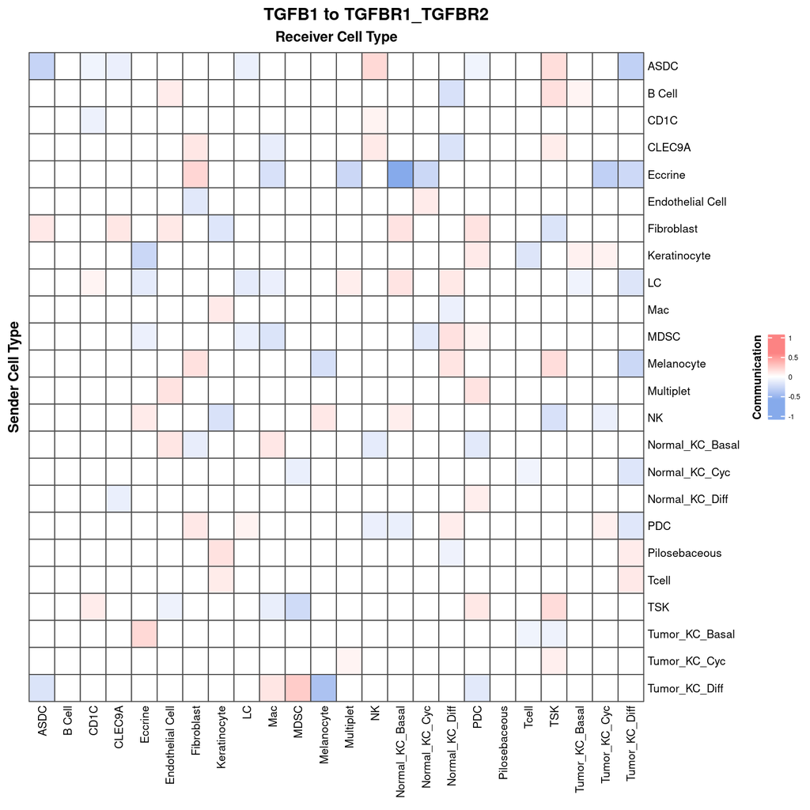

```r
CCCHeatmap(restab, ligand="TGFB1", receptor="TGFBR1_TGFBR2")
```

### 1.3.2 Network

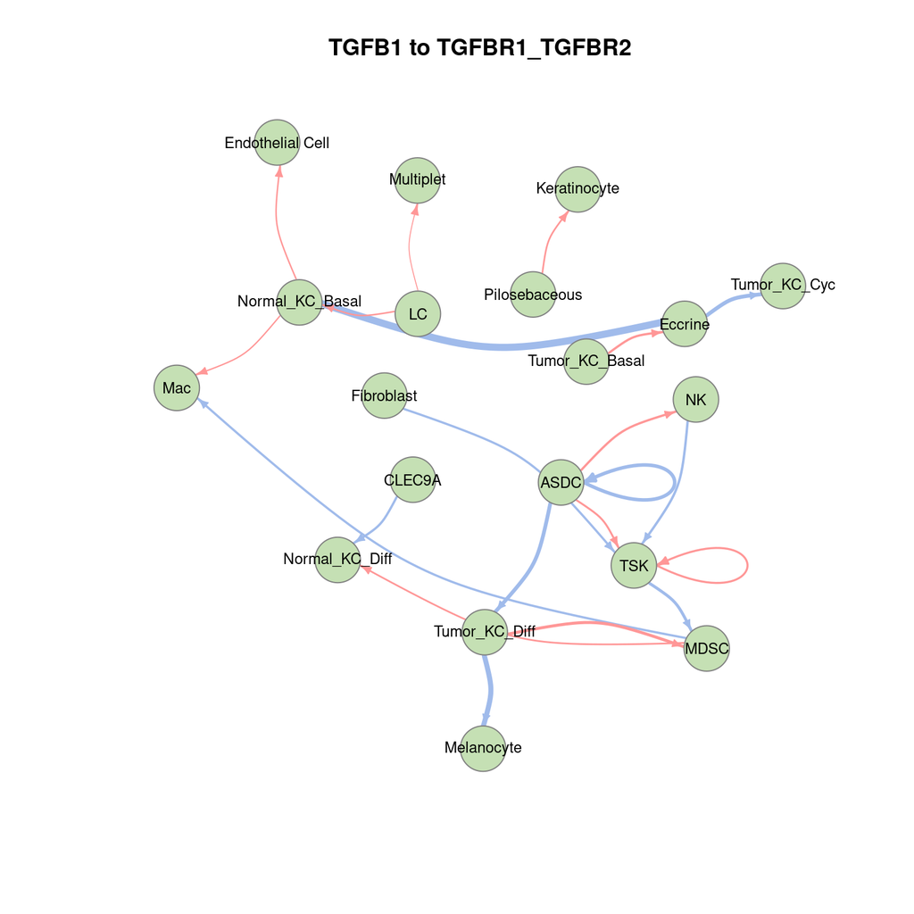

```r
CCCNetwork(restab, ligand="TGFB1", receptor="TGFBR1_TGFBR2", cutoff=0.01)
```

# 2 Inference of cell-cell communication from single-cell resolution SRT data

To demonstrate the inference from single-cell resolution data, we simply treat the `STdata` as if it were single-cell resolution data. We then identify the cell type with the highest proportion in `MExample` and assign that cell type to the specific ‘cell’. Notice that the specific cell type information should be stored within the meta data (e.g., `STmeta`).

```r
STmeta$cell_type <- colnames(MExample)[apply(MExample, 1, which.max)]
STmeta[1:5, ]
```

```
#>        spot  x  y     cell_type
#> spot1 spot1 10 10 Tumor_KC_Diff
#> spot2 spot2 10 12 Tumor_KC_Diff
#> spot3 spot3 10 14           TSK
#> spot4 spot4 10 16 Tumor_KC_Diff
#> spot5 spot5 10 18           TSK
```

## 2.1 Data and preprocessing

**Cell type identification matrix:** Assuming we already know the cell type information for each cell, we can use `CellTypeMatrix()` to generate the corresponding matrix for cell type identification. This matrix, where rows represent cells and columns represent cell types, can be used in subsequent analyses.

```r
Mnew <- CellTypeMatrix(stmeta=STmeta, celltype="cell_type")
Mnew[1:10, 1:5]
```

```
#>       Eccrine Endothelial Cell Fibroblast Keratinocyte Basal
#>  [1,]       0                0          0            0     0
#>  [2,]       0                0          0            0     0
#>  [3,]       0                0          0            0     0
#>  [4,]       0                0          0            0     0
#>  [5,]       0                0          0            0     0
#>  [6,]       0                0          0            0     0
#>  [7,]       0                0          0            0     0
#>  [8,]       0                0          1            0     0
#>  [9,]       0                0          1            0     0
#> [10,]       0                0          1            0     0
```

## 2.2 Inferring cell-cell communication

All the following steps should be the same as the inference for the spot-based SRT data demonstrated above.

The necessary inputs for `FRETCOM()` include the normalized gene expression matrix (`stdat`), the cell type proportion matrix (`M`), the X and Y coordinates (`coordx` and `coordy`), the known ligand-receptor pairs (`ligands` and `receptors`), and the maximum distance allowed for communication (`maxdist`). It is important to note that a reasonable `maxdist` should be set based on the units of `coordx` and `coordy` provided.

For simplicity, we use only the first five ligand-receptor pairs as examples.

```r
restab <- FRETCOM(stdat=stdat, M=Mnew, ligands=ligands[1:5], receptors=receptors[1:5],
                  coordx=STmeta$x, coordy=STmeta$y, maxdist=3)
```

```
#> 1 out of 5 LR pairs have been removed due to their non-existence in SRT data.
#> 109 out of 144 cell type interactions have been removed due to a lack of information.
#> LR pairs: 1
#> Rho = 0.2: AIC = 25534.2911313402
#> Rho = 0.5: AIC = 25668.8138024919
#> Rho = 0.8: AIC = 25775.9097631622
#> LR pairs: 2
#> Rho = 0.2: AIC = 15262.1492792209
#> Rho = 0.5: AIC = 15384.9833733464
#> Rho = 0.8: AIC = 15537.7541020411
#> LR pairs: 3
#> Rho = 0.2: AIC = 19911.3365097308
#> Rho = 0.5: AIC = 20013.2163967398
#> Rho = 0.8: AIC = 20084.0373187372
#> LR pairs: 4
#> Rho = 0.2: AIC = 20203.7483599182
#> Rho = 0.5: AIC = 20322.2797642741
#> Rho = 0.8: AIC = 20409.2901310815
```

```r
restab[1:5, ]
```

```
#>   Ligand      Receptor  CellType_Sender CellType_Receiver   Estimate
#> 1  TGFB1 TGFBR1_TGFBR2          Eccrine           Eccrine -2.2573237
#> 2  TGFB1 TGFBR1_TGFBR2          Eccrine        Fibroblast -2.8355718
#> 3  TGFB1 TGFBR1_TGFBR2          Eccrine              Diff -1.8648918
#> 4  TGFB1 TGFBR1_TGFBR2 Endothelial Cell        Fibroblast -0.1977158
#> 5  TGFB1 TGFBR1_TGFBR2 Endothelial Cell               TSK -0.0101685
#>        Pvalue      Qvalue
#> 1 0.974890327 0.978119266
#> 2 0.967048643 0.978119266
#> 3 0.978119266 0.978119266
#> 4 0.001683652 0.007576435
#> 5 0.549212355 0.681780855
```

```r
restab_LR <- paste0("Ligand: ", restab$Ligand, "; Receptor: ", restab$Receptor)
unique(restab_LR)
```

```
#> [1] "Ligand: TGFB1; Receptor: TGFBR1_TGFBR2"
#> [2] "Ligand: TGFB3; Receptor: TGFBR1_TGFBR2"
#> [3] "Ligand: TGFB1; Receptor: ACVR1B_TGFBR2"
#> [4] "Ligand: TGFB1; Receptor: ACVR1C_TGFBR2"
```

## 2.3 Visualization

In practice, we highly recommend that users generate figures using the results data frame (`restab`) themselves so that features in the figures, such as titles, colors, and font sizes, can be adjusted flexibly. However, we still provide two functions `CCCHeatmap()` and `CCCNetwork()` here for simple visualizations.

### 2.3.1 Heatmap

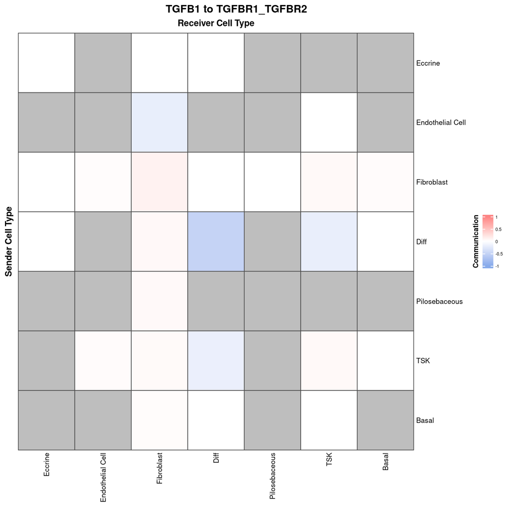

```r
CCCHeatmap(restab, ligand="TGFB1", receptor="TGFBR1_TGFBR2")
```

### 2.3.2 Network

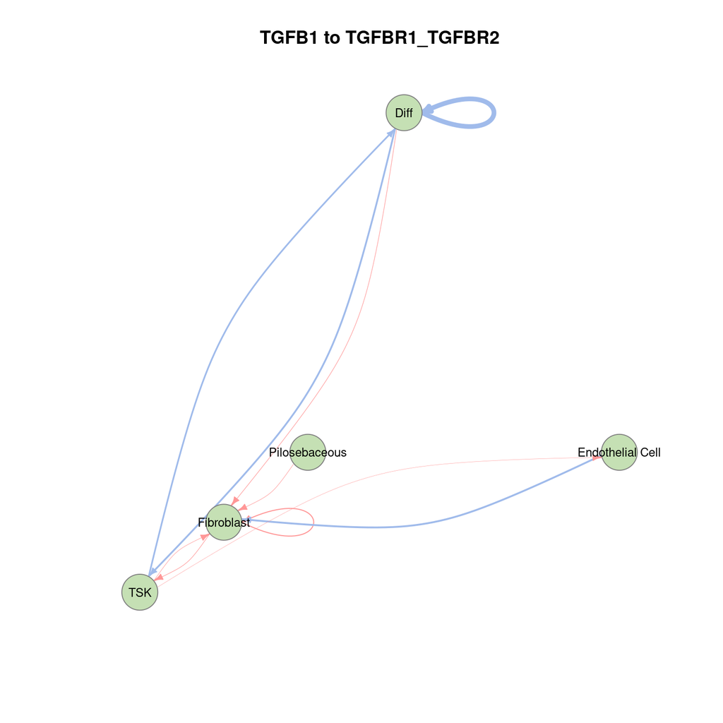

```r
CCCNetwork(restab, ligand="TGFB1", receptor="TGFBR1_TGFBR2", cutoff=0.05)
```